# Tipos de datos

Osmar Dominique

2025-08-13

# Variables

Una variable es una característica de interés que posee cada elemento de la población y que podemos medir. Tenemos diferentes tipo de variables:

- **Cualitativas**. Describen cualidades o atributos. Ejemplos:
  - Color de bicicleta (azul, blanco, verde, amarillo) (Datos categóricos)
  - Tamaño de bicicleta (pequeña, mediana, grande) (Datos ordinales)
  - Calidad de bicicleta (mala, regular, buena) (Datos nominales)
- **Cuantitativas discretas**. Números enteros. Ejemplos:
  - Peso
  - Ruedas
  - Cascos
- **Cuantitativas continuas**. Números reales. Ejemplos:
  - Precios
  - Diametro de ruedas.

## Tipos de gráficos.

Consideremos la base de datos sobre el estudio de la venta de bicicletas. Esta base contiene información sobre 30 autos y variables como: color, tamaño, calidad, peso, ruedas, cascos, precios y diámetro.

La base de datos es:

```r
bicicletas <- data.frame(color, tamaño, calidad, pesos, ruedas, cascos, precio, diametro)   #Si queremos cambiar el nombre a una variable, "Nuevo_nombre" = variable
head(bicicletas)   #solo muestra las primeras observaciones
```

```
##    color  tamaño calidad pesos ruedas cascos precio diametro
## 1  verde  grande regular    14      4      3   4208      669
## 2  verde pequeña   buena    10      2      3   7991      680
## 3 blanco pequeña regular    15      4      1   5357      752
## 4 blanco mediana regular     9      2      2   8741      748
## 5  verde  grande   buena    14      2      2   6071      777
## 6  negro  grande   buena    14      4      1  10749      716
```

```r
print(bicicletas)
```

```
##       color  tamaño calidad pesos ruedas cascos precio diametro
## 1     verde  grande regular    14      4      3   4208      669
## 2     verde pequeña   buena    10      2      3   7991      680
## 3    blanco pequeña regular    15      4      1   5357      752
## 4    blanco mediana regular     9      2      2   8741      748
## 5     verde  grande   buena    14      2      2   6071      777
## 6     negro  grande   buena    14      4      1  10749      716
## 7  amarillo pequeña    mala    10      2      2  10733      669
## 8      azul  grande regular     9      4      3   8759      738
## 9    blanco pequeña regular     9      4      3   4909      751
## 10    verde  grande    mala     9      4      1   4619      676
## 11    negro mediana regular    12      4      2   7663      708
## 12    verde pequeña    mala     9      2      1   4994      687
## 13    verde mediana    mala     9      2      2   7155      667
## 14     azul pequeña regular    15      2      3   9239      708
```

[output cut: 16 more lines]

```r
str(bicicletas)
```

```
## 'data.frame':    30 obs. of  8 variables:
##  $ color   : chr  "verde" "verde" "blanco" "blanco" ...
##  $ tamaño  : chr  "grande" "pequeña" "pequeña" "mediana" ...
##  $ calidad : chr  "regular" "buena" "regular" "regular" ...
##  $ pesos   : num  14 10 15 9 14 14 10 9 9 9 ...
##  $ ruedas  : num  4 2 4 2 2 4 2 4 4 4 ...
##  $ cascos  : num  3 3 1 2 2 1 2 3 3 1 ...
##  $ precio  : num  4208 7991 5357 8741 6071 ...
##  $ diametro: num  669 680 752 748 777 716 669 738 751 676 ...
```

Primero veamos gráficos para datos cualitativos nominales:

## Color

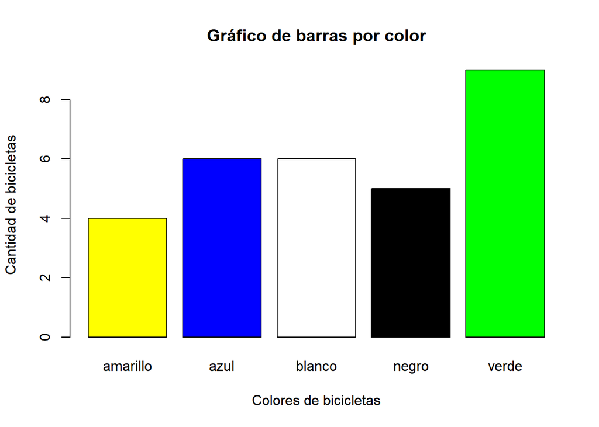

Podemos observar que las bicicletas más vendidas son de color verde, azul y blanco. Mientras que las menos vendidas son las de color amarillo y negro.

### Tamaño

[figure not shown]

Podemos observar que las bicicletas más vendidas fueron pequeñas. Mientras que las menos vendidas son medianas.

### Calidad

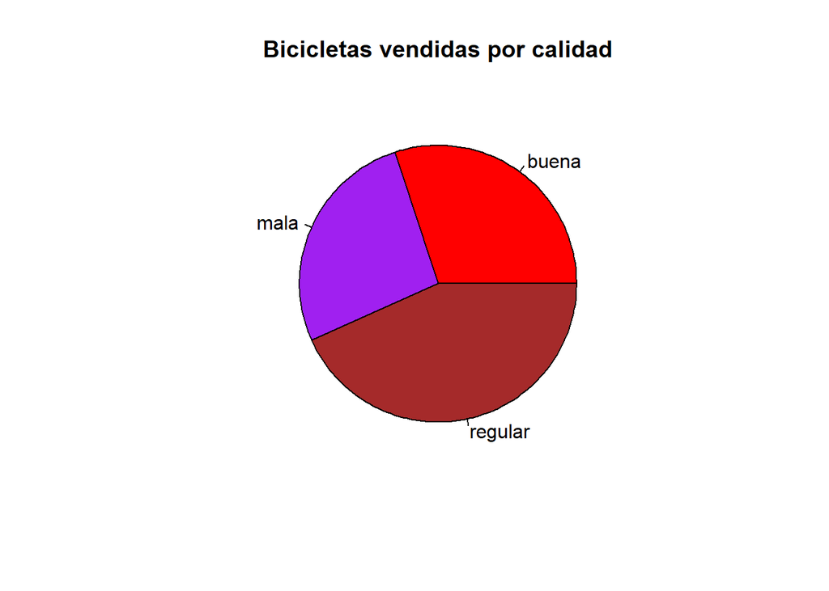

Podemos observar que las bicicletas más vendidas fueron de calidad regular. Mientras que las menos vendidas son de calidad mala.

### Peso

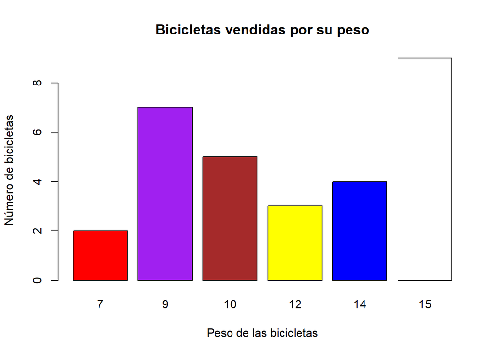

Podemos observar que los pesos de las bicletas más vendidas son de 15, 9 y 10 kilogramos. Mientras que las menos vendidas son: de 14, 12, 7 kilogramos.

### Número de ruedas

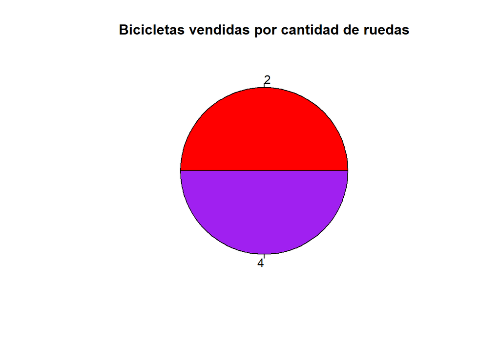

Observamos que tanto bicicletas con dos ruedas como aquellas con 4 fueron vendidas.

### Cascos incluidos

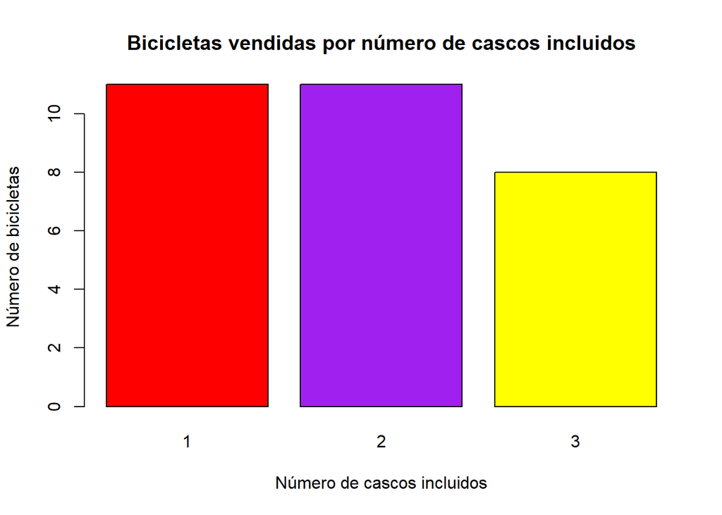

Observamos que las bicicletas más vendidas son las que tienen uno o dos cascos. Mientras que las menos vendidas son las de tres cascos.

Por último, tenemos para variables cuantitativas continuas:

### Precio

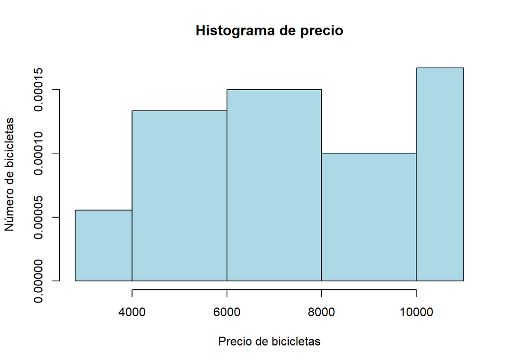

### Diametro de las ruedas

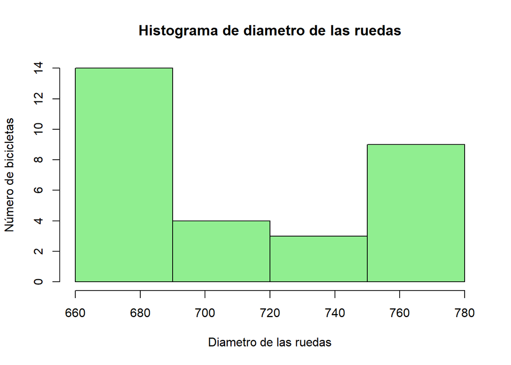

Las bicicletas más vendidas tienen diametro de 660 a 690 y de 750 780 milímetros. Mientras que las menos vendidas van de los 690 a los 750 milímetros